# OR538 Final Project - Step 3: Data Modeling

# Modeling Paycheck Inc.

```r
pacman::p_load("forecast") # Library needed for auto.arima

fitPayx <- auto.arima(df_log_ret[,"PAYX"], max.p = 20, max.q = 20, max.d = 20, ic = "aic")
fitPypl <- auto.arima(df_log_ret[,"PYPL"], max.p = 20, max.q = 20, max.d = 20, ic = "aic")
fitWmt <- auto.arima(df_log_ret[,"WMT"], max.p = 20, max.q = 20, max.d = 20, ic = "aic")
fitSp <- auto.arima(df_log_ret[,"SP"], max.p = 20, max.q = 20, max.d = 20, ic = "aic")

fitPayxRes <- c(round(fitPayx$bic,3), round(fitPayx$aic,3),
                round(fitPayx$aicc,3), "ARIMA(0,0,0)")
fitPyplRes <- c(round(fitPypl$bic,3), round(fitPypl$aic,3),
                round(fitPypl$aicc,3), "ARIMA(1,0,1) = ARMA(1,1)")
fitWmtRes <- c(round(fitWmt$bic,3), round(fitWmt$aic,3),
               round(fitWmt$aicc,3), "ARIMA(0,0,0)")
fitSpRes <- c(round(fitSp$bic,3), round(fitSp$aic,3),
              round(fitSp$aicc,3), "ARIMA(0,0,0)")

df_fit_results <- as.data.frame(rbind(fitPayxRes, fitPyplRes, fitWmtRes, fitSpRes))
colnames(df_fit_results) <- c("BIC", "AIC", "AICc", "Model")
rownames(df_fit_results) <- c("PayCheck Inc.", "Paypal", "Walmart", "S&P 500")

df_fit_results
```

|  | BIC | AIC | AICc | Model |
| --- | --- | --- | --- | --- |
| PayCheck Inc. | -3045.397 | -3049.616 | -3049.608 | ARIMA(0,0,0) |
| Paypal | -2530.806 | -2543.462 | -2543.414 | ARIMA(1,0,1) = ARMA(1,1) |
| Walmart | -2969.089 | -2973.308 | -2973.3 | ARIMA(0,0,0) |
| S&P 500 | -2756.626 | -2760.845 | -2760.837 | ARIMA(0,0,0) |

**Table 2:**

Table **2** allow us to observe that only the Paypal securities needed a greater order to find the best ARIMA model.

# PayCheck Inc. Training Model Observations

```r
pdf(file = paste(folder,"Figure7-PayCheck Model Results.pdf"),height=7,width=8)
#
par(mfrow=c(2,2))
acf(df_log_ret[,"PAYX"], main="PayCheck Inc.", na.action = na.pass)
acf(fitPayx$residual, main = "PayCheck Inc. Residuals", na.action = na.pass)
```

```r
qqnorm(fitPayx$resid, datax = T, main="PayCheck Inc. Residuals QQNorm")
qqline(fitPayx$resid, datax = T)
plot(ts(fitPayx$resid),ylab="Residual",main="PayCheck Inc. Residuals Time-Series")
```

```r
#
graphics.off()

par(mfrow=c(2,2))

acf(df_log_ret[,"PAYX"], main="PayCheck Inc.", na.action = na.pass)
```

```r
acf(fitPayx$residual, main = "PayCheck Inc. Residuals", na.action = na.pass)
qqnorm(fitPayx$resid, datax = T, main="PayCheck Inc. Residuals QQNorm")
```

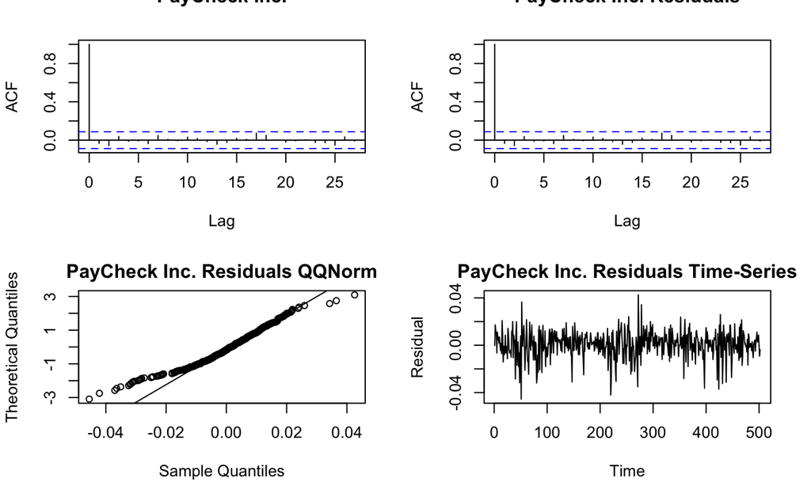

```r
qqline(fitPayx$resid, datax = T)
plot(ts(fitPayx$resid),ylab="Residual",main="PayCheck Inc. Residuals Time-Series")
```

**Figure 7:** PayCheck Training Model Validation

PayCheck Inc. ACF plots presented in figure **7** confirms that the residuals follow the same autocorrelation than the original dataset. This similarity makes the ARIMA(0,0,0) a good model to be used for forecasting.

The QQnorm plot of PayCheck Inc. reiduals present heavy tails, a common characteristic of t-distributions. This behavior doesn’t align with the expected normal distribution for residuals.

The time-series plot of PayCheck Inc. residuals shows some volatility; in particular around the 50th observation, and between the 250th and 300th time observation.

```r
pdf(file = paste(folder,"Figure8-Paypal Model Results.pdf"),height=7,width=8)
#
par(mfrow=c(2,2))
acf(df_log_ret[,"PYPL"], main="Paypal", na.action = na.pass)
acf(fitPypl$residual, main = "Paypal Residuals", na.action = na.pass)
```

```r
qqnorm(fitPypl$resid, datax = T, main="Paypal Residuals QQNorm")
qqline(fitPypl$resid, datax = T)
plot(ts(fitPypl$resid),ylab="Residual",main="Paypal Residuals Time-Series")
```

```r
#
graphics.off()

par(mfrow=c(2,2))

acf(df_log_ret[,"PYPL"], main="Paypal", na.action = na.pass)
```

```r
acf(fitPypl$residual, main = "Paypal Residuals", na.action = na.pass)
qqnorm(fitPypl$resid, datax = T, main="Paypal Residuals QQNorm")
```

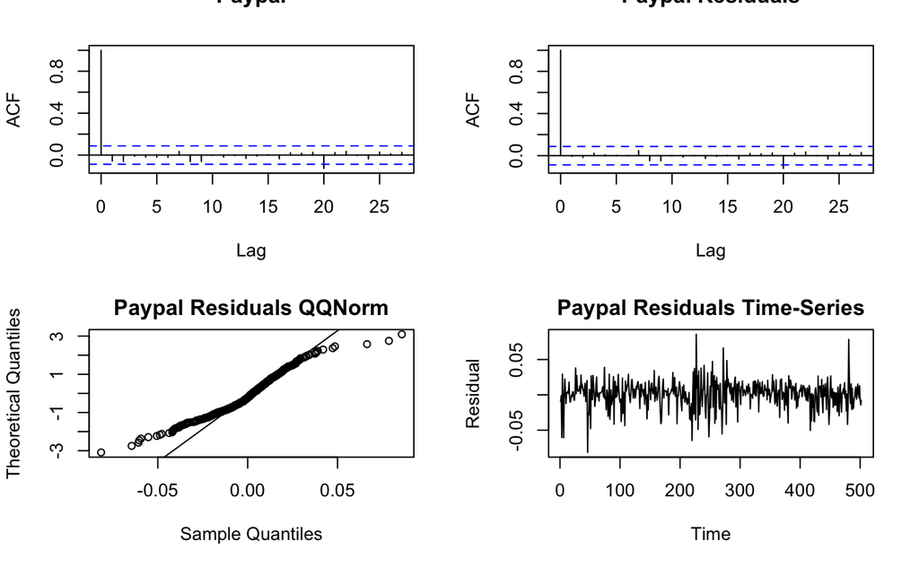

```r
qqline(fitPypl$resid, datax = T)
plot(ts(fitPypl$resid),ylab="Residual",main="Paypal Residuals Time-Series")
```

**Figure 8:** Paypal Training Model Validation

Paypal ACF plots presented in figure **8** confirms that the residuals follow the same autocorrelation than the original dataset; in particular at lag 20 both ACF plots present an autocorrelation that crosses the lower test bound. This similarity makes the ARIMA(1,0,1) {i.e., ARMA(1,1)} a good model to be used for forecasting.

The QQnorm plot of Paypal residuals present heavy tails, a common characteristic of t-distributions. This behavior doesn’t align with the expected normal distribution for residuals.

The time-series plot of Paypal residuals shows some volatility; in particular around the 50th observation, between the 200th and 300th time observation, and between 450th and 500th time observation.

```r
pdf(file = paste(folder,"Figure9-Walmart Model Results.pdf"),height=7,width=8)
#
par(mfrow=c(2,2))
acf(df_log_ret[,"WMT"], main="Walmart", na.action = na.pass)
acf(fitWmt$residual, main = "Walmart Residuals", na.action = na.pass)
```

```r
qqnorm(fitWmt$resid, datax = T, main="Walmart Residuals QQNorm")
qqline(fitWmt$resid, datax = T)
plot(ts(fitWmt$resid),ylab="Residual",main="Walmart Residuals Time-Series")
```

```r
#
graphics.off()

par(mfrow=c(2,2))

acf(df_log_ret[,"WMT"], main="Walmart", na.action = na.pass)
```

```r
acf(fitWmt$residual, main = "Walmart Residuals", na.action = na.pass)
qqnorm(fitWmt$resid, datax = T, main="Walmart Residuals QQNorm")
```

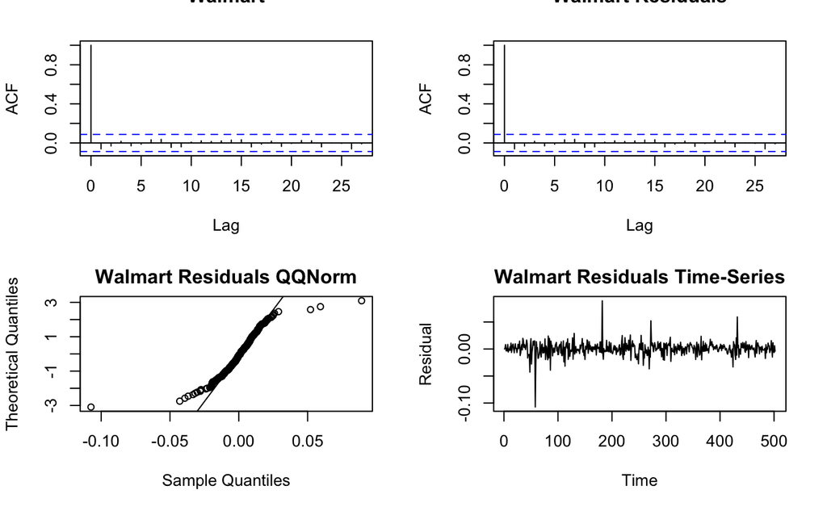

```r
qqline(fitWmt$resid, datax = T)
plot(ts(fitWmt$resid),ylab="Residual",main="Walmart Residuals Time-Series")
```

**Figure 9:** Walmart Training Model Validation

Walmart ACF plots presented in figure **9** confirms that the residuals follow the same autocorrelation than the original dataset. This similarity makes the ARIMA(0,0,0) a good model to be used for forecasting.

The QQnorm plot of Walmart residuals present heavy tails, a common characteristic of t-distributions. This behavior doesn’t align with the expected normal distribution for residuals.

The time-series plot for Walmart residuals shows some volatility; in particular between 50th and 100th time observations, and close to the 200th time observation.

```r
pdf(file = paste(folder,"Figure10-SP500 Model Results.pdf"),height=7,width=8)
#
par(mfrow=c(2,2))
acf(df_log_ret[,"SP"], main="S&P 500", na.action = na.pass)
acf(fitSp$residual, main = "S&P 500 Residuals", na.action = na.pass)
```

```r
qqnorm(fitSp$resid, datax = T, main="S&P 500 Residuals QQNorm")
qqline(fitSp$resid, datax = T)
plot(ts(fitSp$resid),ylab="Residual",main="S&P 500 Residuals Time-Series")
```

```r
#
graphics.off()

par(mfrow=c(2,2))

acf(df_log_ret[,"SP"], main="S&P 500", na.action = na.pass)
```

```r
acf(fitSp$residual, main = "S&P 500 Residuals", na.action = na.pass)
qqnorm(fitSp$resid, datax = T, main="S&P 500 Residuals QQNorm")
```

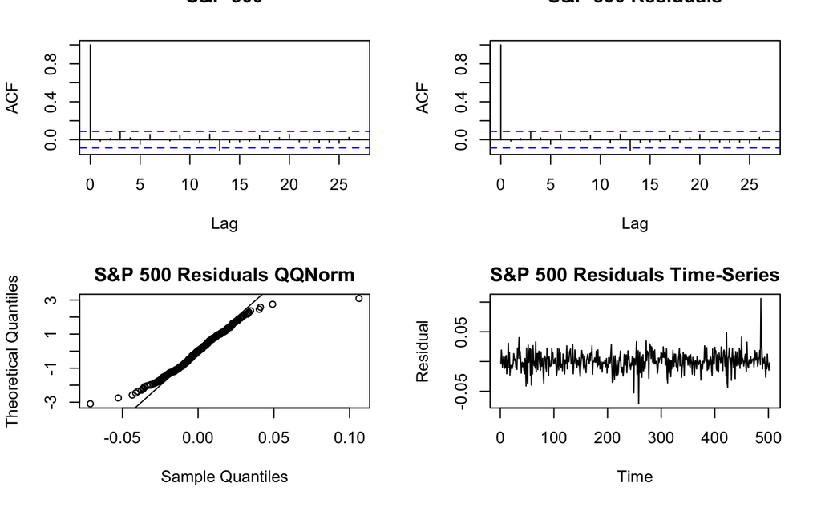

```r
qqline(fitSp$resid, datax = T)
plot(ts(fitSp$resid),ylab="Residual",main="S&P 500 Residuals Time-Series")
```

**Figure 10:** S&P 500 Training Model Validation

The QQnorm plot of S&P 500 residuals present heavy tails, a common characteristic of t-distributions. This behavior doesn’t align with the expected normal distribution for residuals.

The time-series plot of S&P 500 residuals shows some volatility; in particular around the 250th observation, and 500th time observation.

```r
pdf(file = paste(folder,"Figure11-Securities Residuals QQ Plot.pdf"),height=7,width=8)
#
par(mfrow=c(2,2))
qqnorm(fitPayx$resid, datax = T, main="PayCheck Inc. Residuals")
qqline(fitPayx$resid, datax = T)
qqnorm(fitPypl$resid, datax = T, main="Paypal Residuals")
```

```r
qqline(fitPypl$resid, datax = T)
qqnorm(fitWmt$resid, datax = T, main="Walmart Residuals")
qqline(fitWmt$resid, datax = T)
qqnorm(fitSp$resid, datax = T, main="S&P 500 Residuals")
```

```r
qqline(fitSp$resid, datax = T)
#
graphics.off()

par(mfrow=c(2,2))
qqnorm(fitPayx$resid, datax = T, main="PayCheck Inc. Residuals")
```

```r
qqline(fitPayx$resid, datax = T)
qqnorm(fitPypl$resid, datax = T, main="Paypal Residuals")
```

```r
qqline(fitPypl$resid, datax = T)
qqnorm(fitWmt$resid, datax = T, main="Walmart Residuals")
```

```r
qqline(fitWmt$resid, datax = T)
qqnorm(fitSp$resid, datax = T, main="S&P 500 Residuals")
```

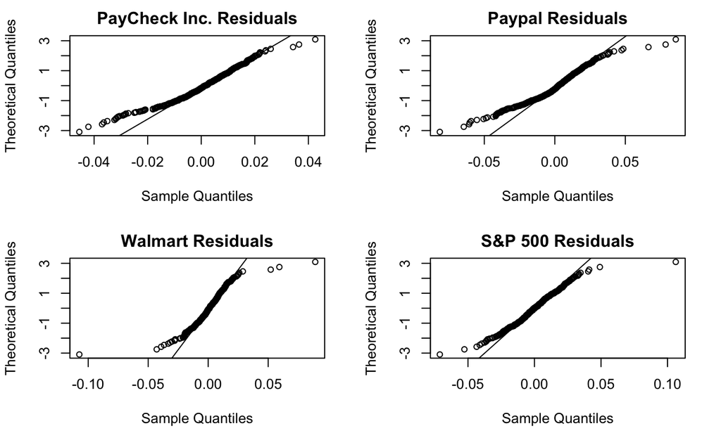

```r
qqline(fitSp$resid, datax = T)
```

**Figure 11:** QQnorm plots for PayCheck Inc., Paypal, Walmart and S&P 500

Figure **11** allow us to observe heavy tails for all securities. However, S&P 500 seems to show the least amount of tail.